# Predicting Cancer Mortality Rate by State

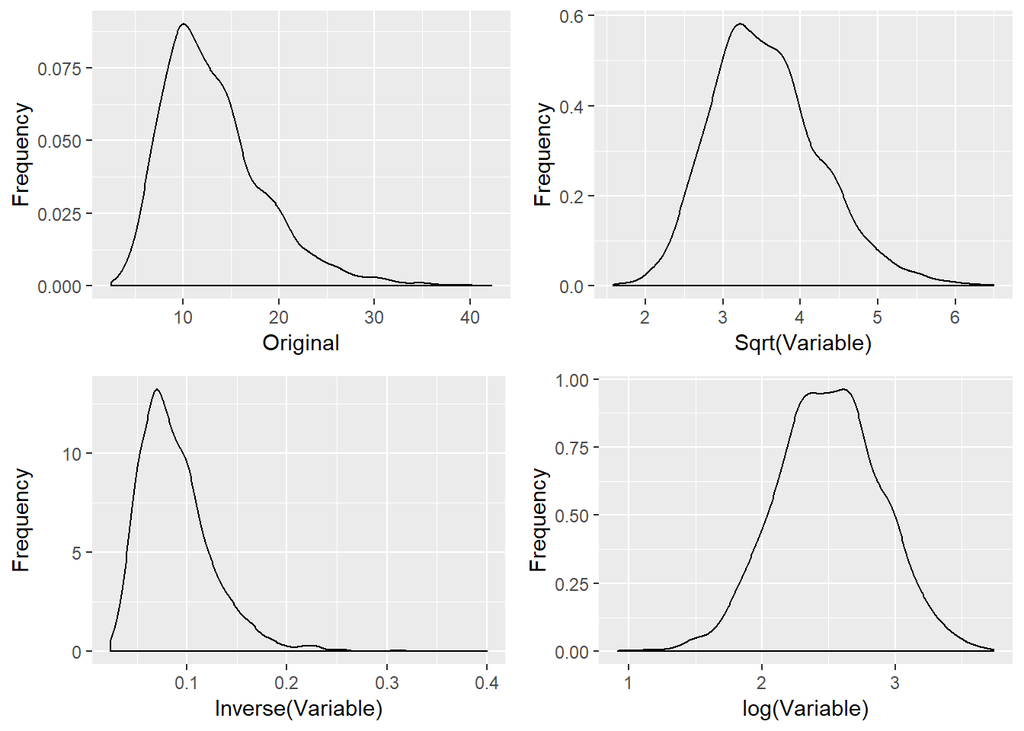

```r
inspection(variable)
```

pct_employed16_over is very slightly left skewed so no transformation is necessary

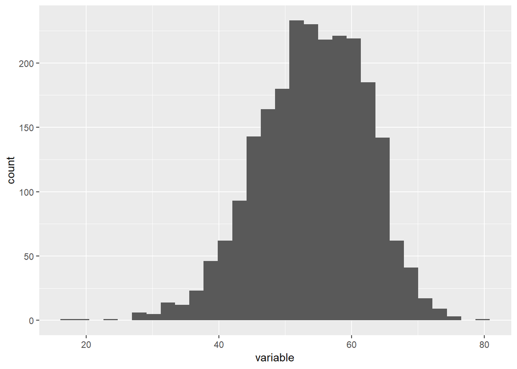

```r
variable = reduced_clean$pct_employed16_over


distribution(variable)
```

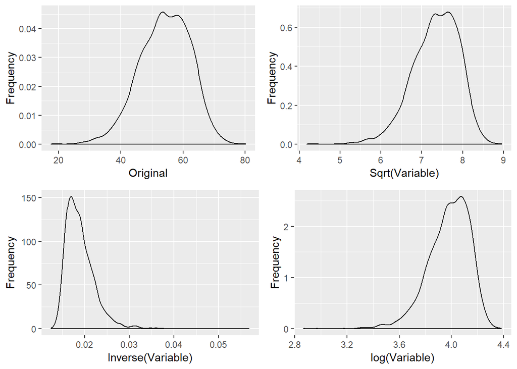

```r
inspection(variable)
```

pct_unemployed16_over is right skewed and a square root transformation works best to reduce skewness

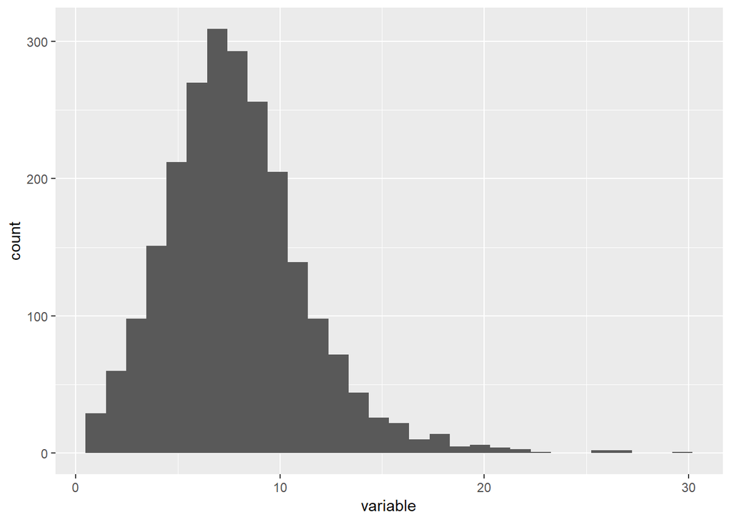

```r
variable = reduced_clean$pct_unemployed16_over


distribution(variable)
```

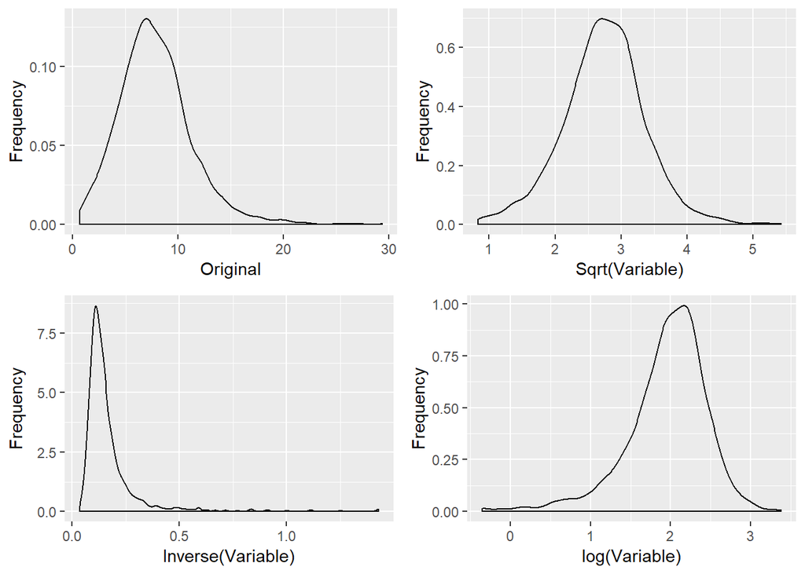

```r
inspection(variable)
```

pct_private_coverage is appropriately shaped (very slight skewness) and no transformation is needed

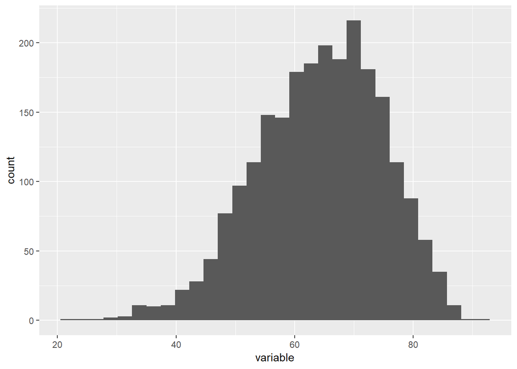

```r
variable = reduced_clean$pct_private_coverage


distribution(variable)
```

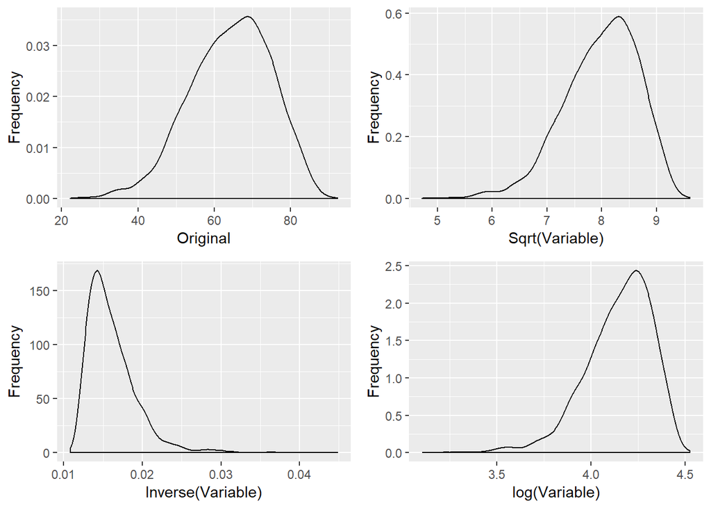

```r
inspection(variable)
```

pct_private_coverage_alone is appropriately shaped and no transformation is needed

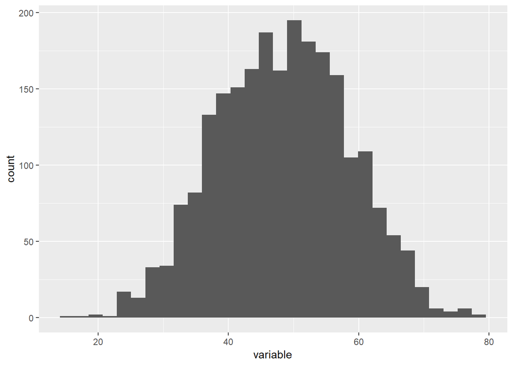

```r
variable = reduced_clean$pct_private_coverage_alone


distribution(variable)
```

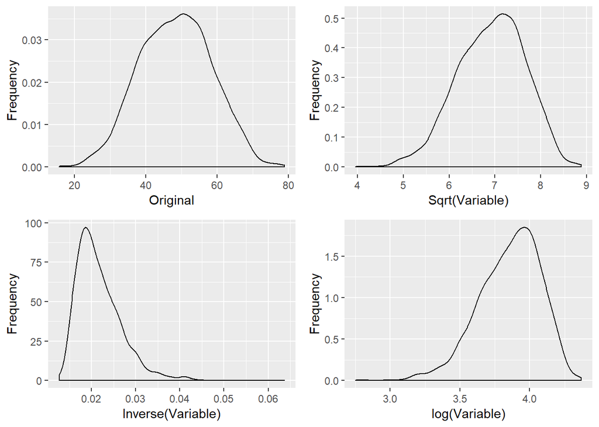

```r
inspection(variable)
```

pct_emp_priv_coverage is appropriately shaped

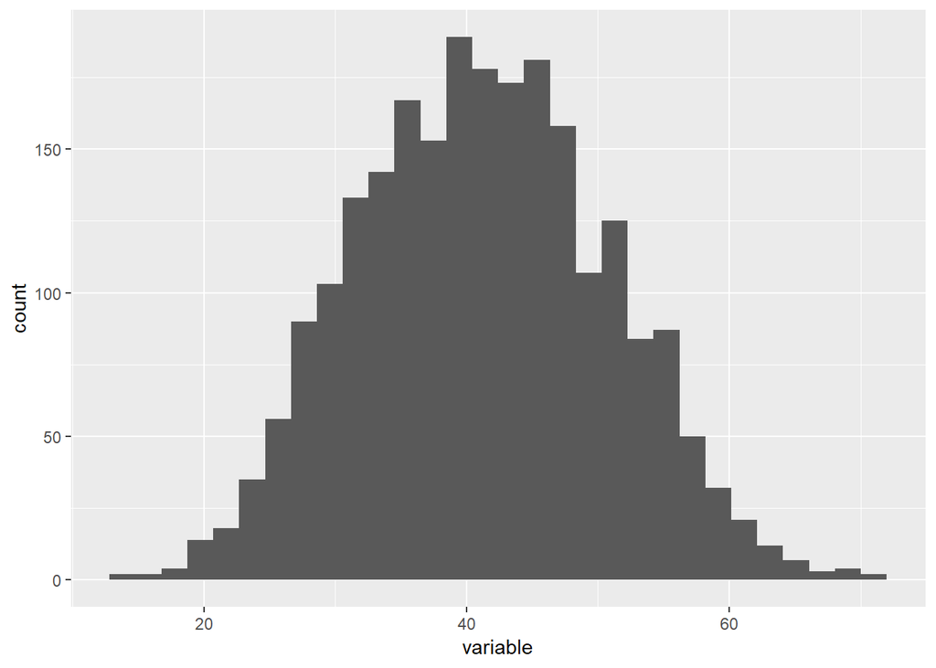

```r
variable = reduced_clean$pct_emp_priv_coverage


distribution(variable)
```

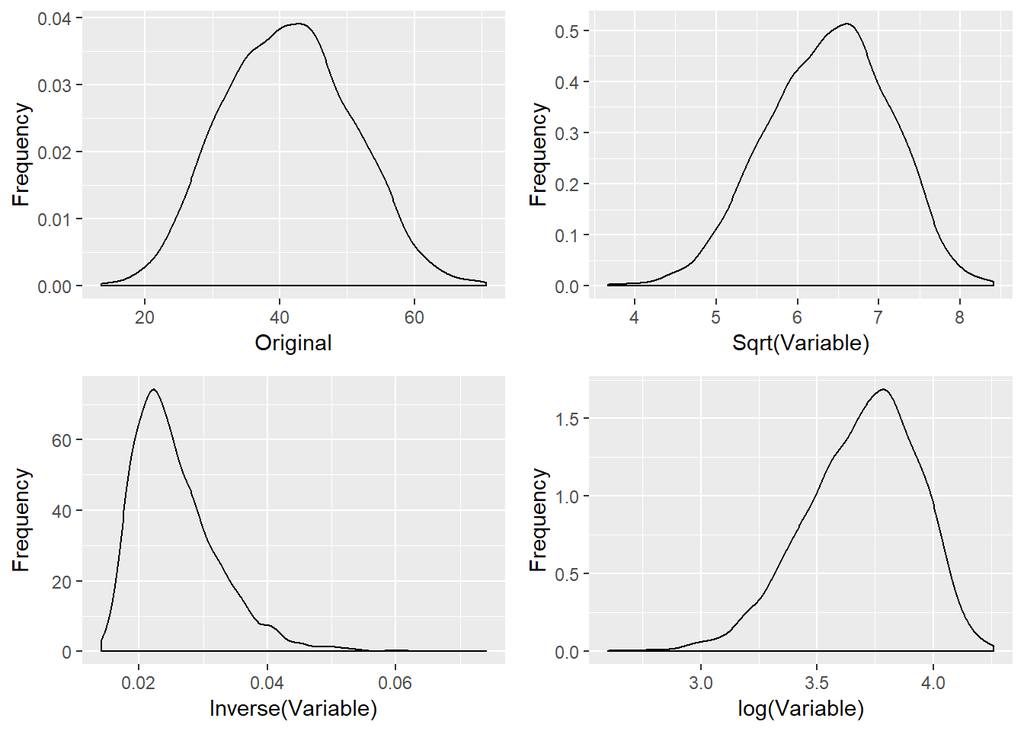

```r
inspection(variable)
```

pct_public_coverage is appropriately shaped

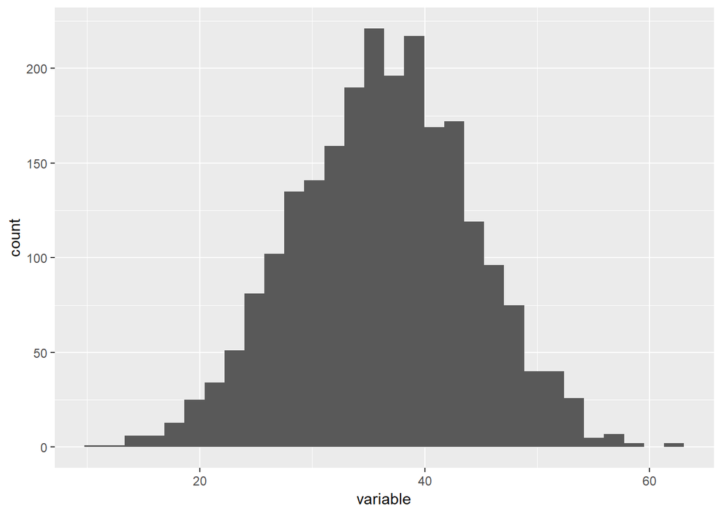

```r
variable = reduced_clean$pct_public_coverage


distribution(variable)
```

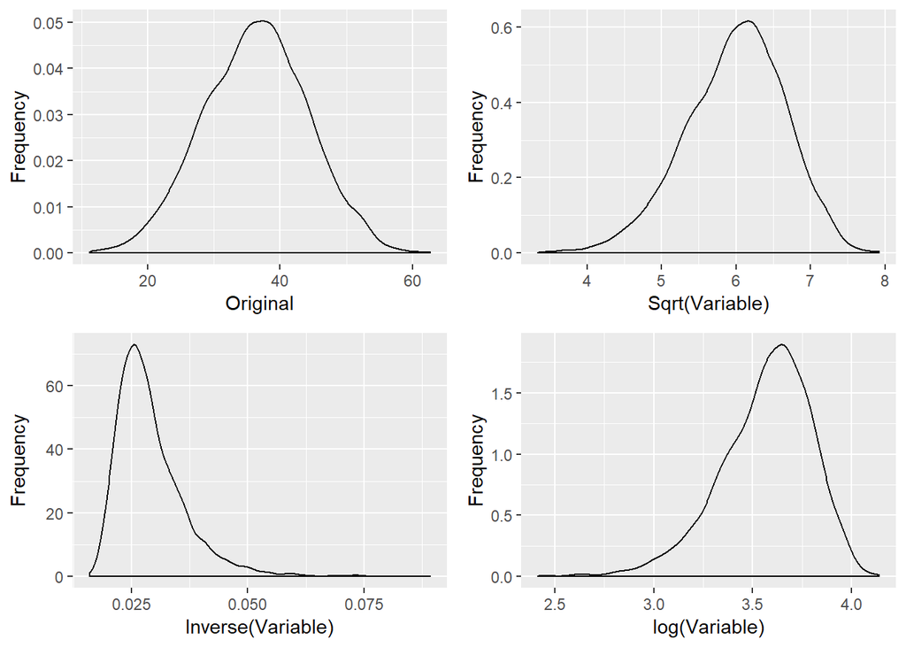

```r
inspection(variable)
```

pct_public_coverage_alone is slightly skewed to the right and the square root transformation reduces the skewness. But a transformation may not be necessary in this case

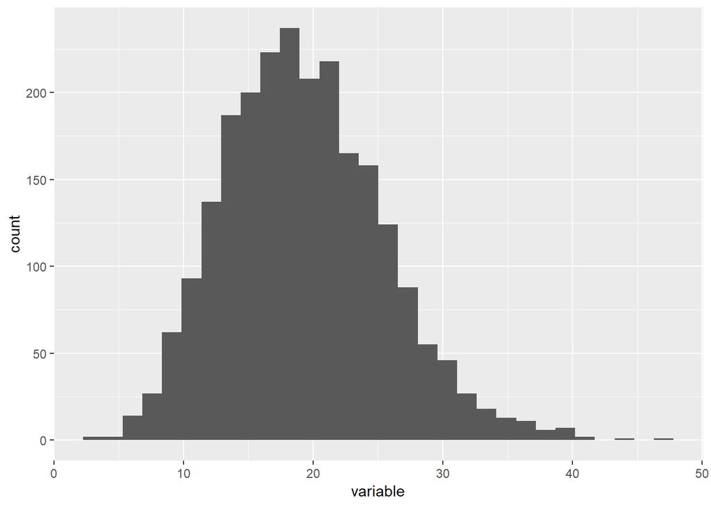

```r
variable = reduced_clean$pct_public_coverage_alone


distribution(variable)
```

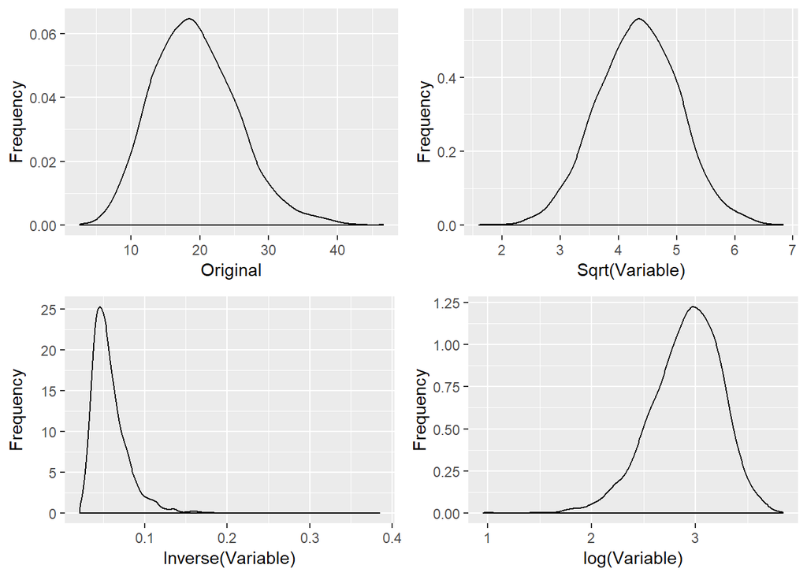

```r
inspection(variable)
```

pct_white is left skewed and no transformation improves the distribution

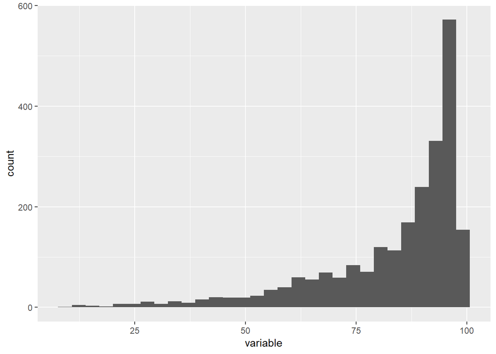

```r
variable = reduced_clean$pct_white


distribution(variable)
```

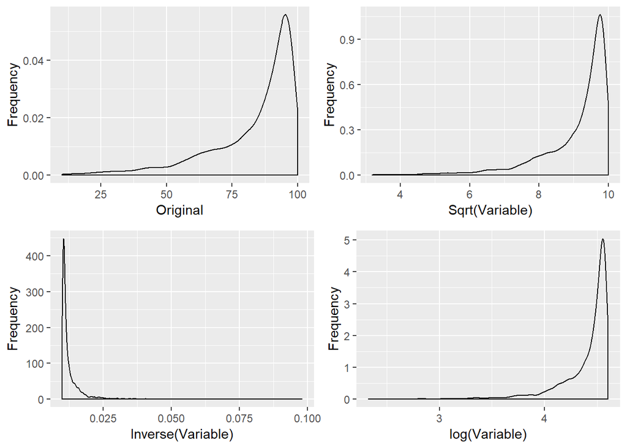

```r
inspection(variable)
```

pct_black is right skewed. Although, log transformation best reduces the skewness, it creates an unusual shape where a majority of the points are concentrated towards the upper half of the curve

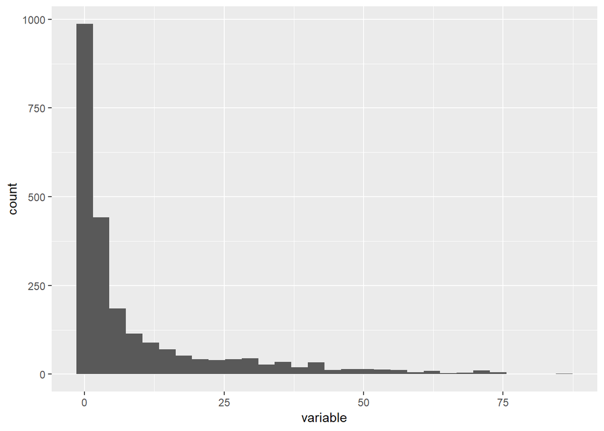

```r
variable = reduced_clean$pct_black + 0.01


distribution(variable)
```

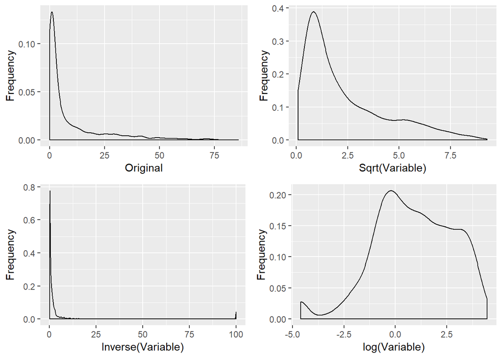

```r
inspection(variable)
```

pct_asian is right skewed and a log transformation reduces the skewness

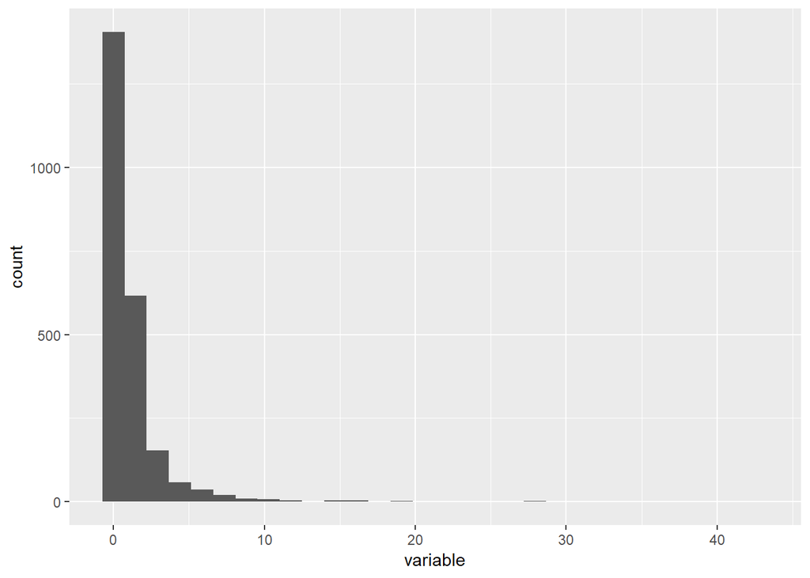

```r
variable = reduced_clean$pct_asian + 0.01


distribution(variable)
```

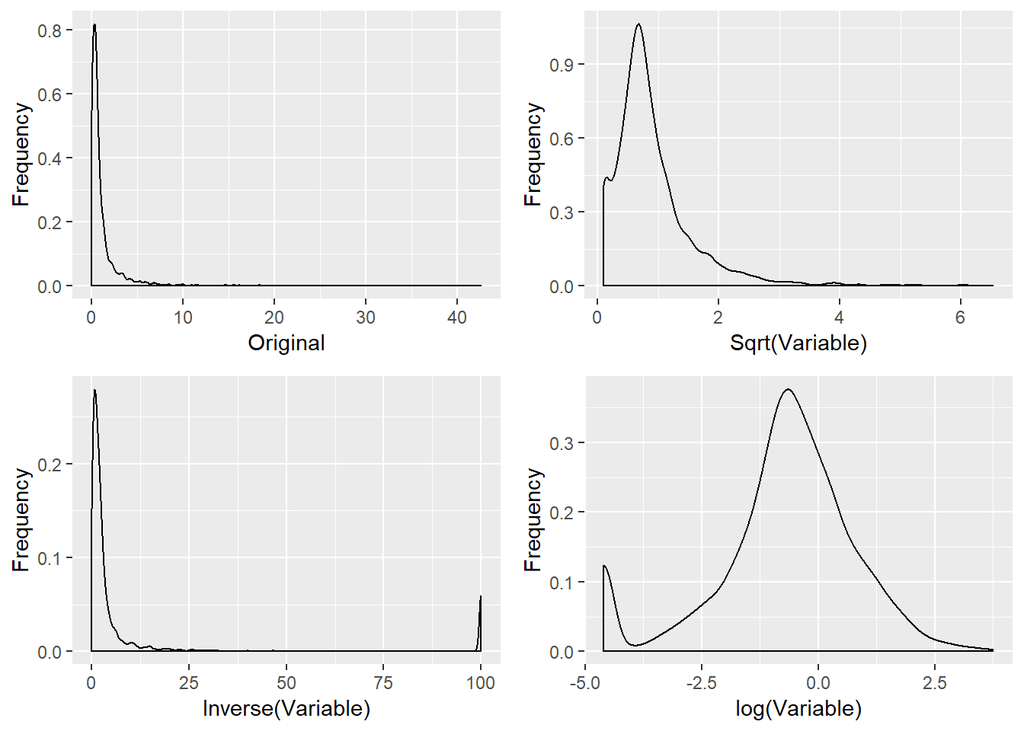

```r
inspection(variable)
```

pct_other_race is right skewed and a log transformation reduces the skewness

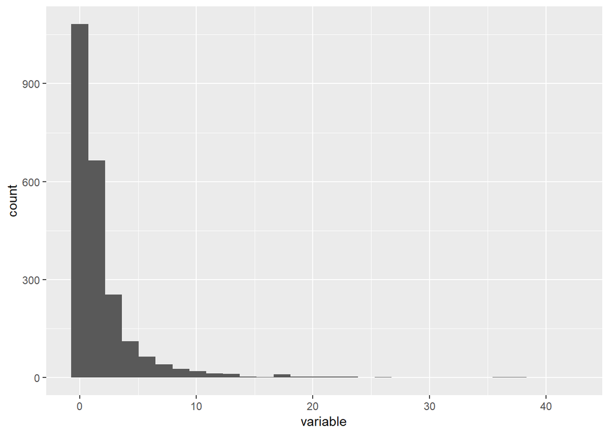

```r
variable = reduced_clean$pct_other_race + 0.01


distribution(variable)
```

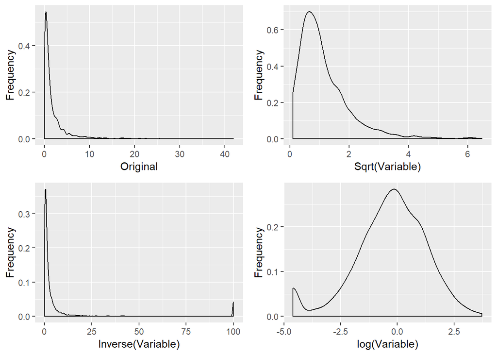

```r
inspection(variable)
```

pct_married_households is appropriately shaped

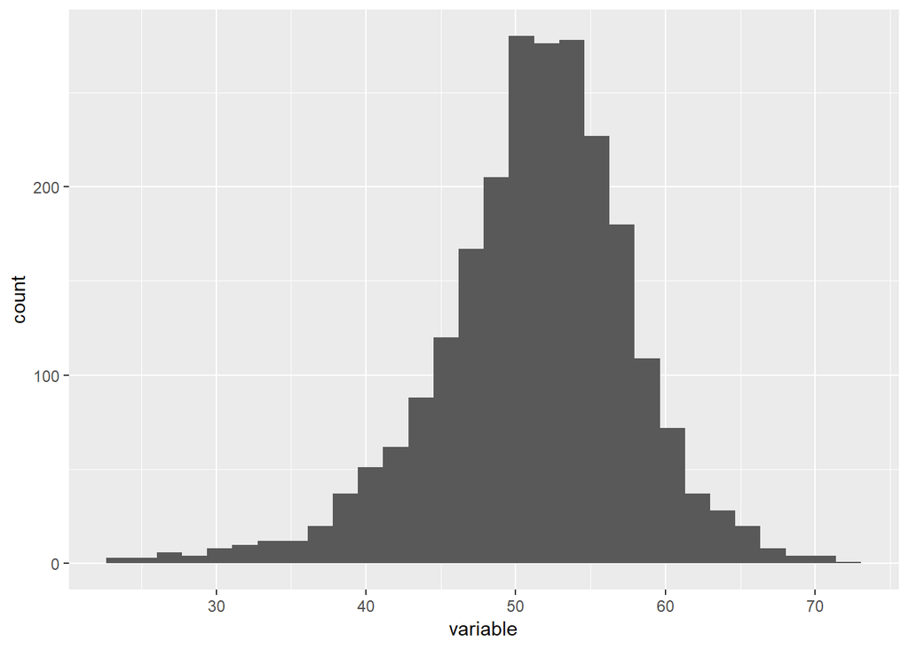

```r
variable = reduced_clean$pct_married_households


distribution(variable)
```

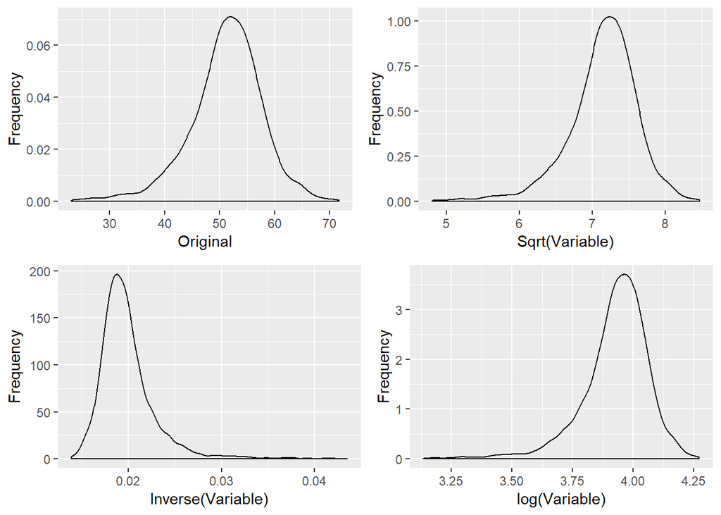

```r
inspection(variable)
```

birth_rate is slightly right skewed and square root transformation reduces the skewness. Although, the transformation might be unnecessary

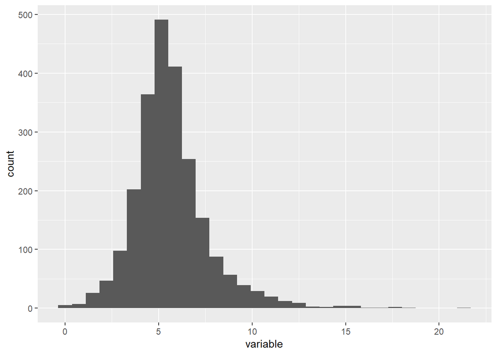

```r
variable = reduced_clean$birth_rate


distribution(variable)
```

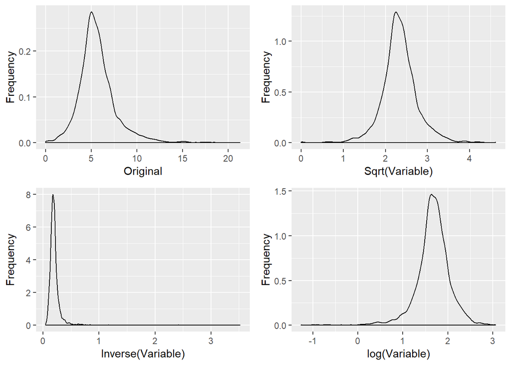

```r
inspection(variable)
```

Perform the aforementioned transformations

```r
model_data =
  cancer_data %>%
  dplyr::select(-pct_some_col18_24) %>%
  na.omit() %>%
  dplyr::select(-c(binned_inc, median_age, avg_deaths_per_year, pop_est2015)) %>%
  mutate(log_avg_ann_count = log(avg_ann_count),
         inverse_med_income = 1/(med_income),
         sqrt_poverty_percent = sqrt(poverty_percent),
         study_per_cap = study_per_cap + 0.01,
         log_study_per_cap = log(study_per_cap),
         log_avg_household_size = log(avg_household_size),
         sqrt_pct_no_hs18_24 = sqrt(pct_no_hs18_24),
         sqrt_pct_bach_deg18_24 = sqrt(pct_bach_deg18_24),
         log_pct_bach_deg25_over = log(pct_bach_deg25_over),
         sqrt_pct_unemployed16_over = sqrt(pct_unemployed16_over),
         sqrt_pct_public_coverage_alone = sqrt(pct_public_coverage_alone),
         pct_black = pct_black + 0.01,
         log_pct_black = log(pct_black),
         pct_asian = pct_asian + 0.01,
         log_pct_asian = log(pct_asian),
         pct_other_race = pct_other_race + 0.01,
         log_other_race = log(pct_other_race),
         sqrt_birth_rate = sqrt(birth_rate))
```

We are interested in creating a predictive model at the state level so we can aggregate the county data to obtain state level estimates (using mean)

```r
model_data_state =
  model_data %>%
  separate(geography, into = c("county", "state"), sep = ",") %>%
  group_by(state) %>%
  dplyr::select(-county) %>%
  summarise(avg_ann_count = mean(avg_ann_count),
            incidence_rate = mean(incidence_rate),
            poverty_percent = mean(poverty_percent),
            pct_no_hs18_24 = mean(pct_no_hs18_24),
            pct_bach_deg18_24 = mean(pct_bach_deg18_24),
            pct_public_coverage_alone = mean(pct_public_coverage_alone),
            pct_asian = mean(pct_asian),
            birth_rate = mean(birth_rate),
            med_income = mean(med_income),
            study_per_cap = mean(study_per_cap),
            median_age_male = mean(median_age_male),
            avg_household_size = mean(avg_household_size),
            pct_hs18_24 = mean(pct_hs18_24),
            pct_hs25_over = mean(pct_hs25_over),
            pct_unemployed16_over = mean(pct_unemployed16_over),
            pct_emp_priv_coverage = mean(pct_emp_priv_coverage),
            pct_white = mean(pct_white),
            pct_other_race = mean(pct_other_race),
            target_death_rate = mean(target_death_rate),
            median_age_female = mean(median_age_female),
            percent_married = mean(percent_married),
            pct_bach_deg25_over = mean(pct_bach_deg25_over),
            pct_private_coverage = mean(pct_private_coverage),
            pct_public_coverage = mean(pct_public_coverage),
            pct_black = mean(pct_black),
            pct_married_households = mean(pct_married_households),
            pct_employed16_over = mean(pct_employed16_over),
            pct_private_coverage_alone = mean(pct_private_coverage_alone),
            log_avg_ann_count = mean(log_avg_ann_count),
            sqrt_poverty_percent = mean(sqrt_poverty_percent),
            sqrt_pct_no_hs18_24 = mean(sqrt_pct_no_hs18_24),
            sqrt_pct_bach_deg18_24 = mean(sqrt_pct_bach_deg18_24),
            sqrt_pct_public_coverage_alone = mean(sqrt_pct_public_coverage_alone),
            log_pct_asian = mean(log_pct_asian),
            sqrt_birth_rate = mean(sqrt_birth_rate),
            inverse_med_income = mean(inverse_med_income),
            log_study_per_cap = mean(log_study_per_cap),
            log_avg_household_size = mean(log_avg_household_size),
            sqrt_pct_unemployed16_over = mean(sqrt_pct_unemployed16_over),
            log_other_race = mean(log_other_race),
            log_pct_bach_deg25_over = mean(log_pct_bach_deg25_over),
            log_pct_black = mean(log_pct_black)) %>%
  dplyr::select(-state)
```

# Modeling (State level)

Create a subset dataset with only the transformed variables

```r
transformed_model_data_state = model_data_state%>%
  dplyr::select(target_death_rate, log_avg_ann_count, incidence_rate, inverse_med_income, sqrt_poverty_percent,
                median_age_male, median_age_female, log_avg_household_size, percent_married,
                sqrt_pct_no_hs18_24, pct_hs18_24, sqrt_pct_bach_deg18_24, pct_hs25_over, pct_bach_deg25_over,
                pct_employed16_over, sqrt_pct_unemployed16_over, pct_private_coverage, pct_private_coverage_alone,
                pct_emp_priv_coverage, pct_public_coverage, sqrt_pct_public_coverage_alone, pct_white,
                pct_married_households, sqrt_birth_rate, log_study_per_cap, log_pct_black, log_pct_asian, log_other_race)
```

Our full model has 27 potential predictors - select model based on criterion procedures

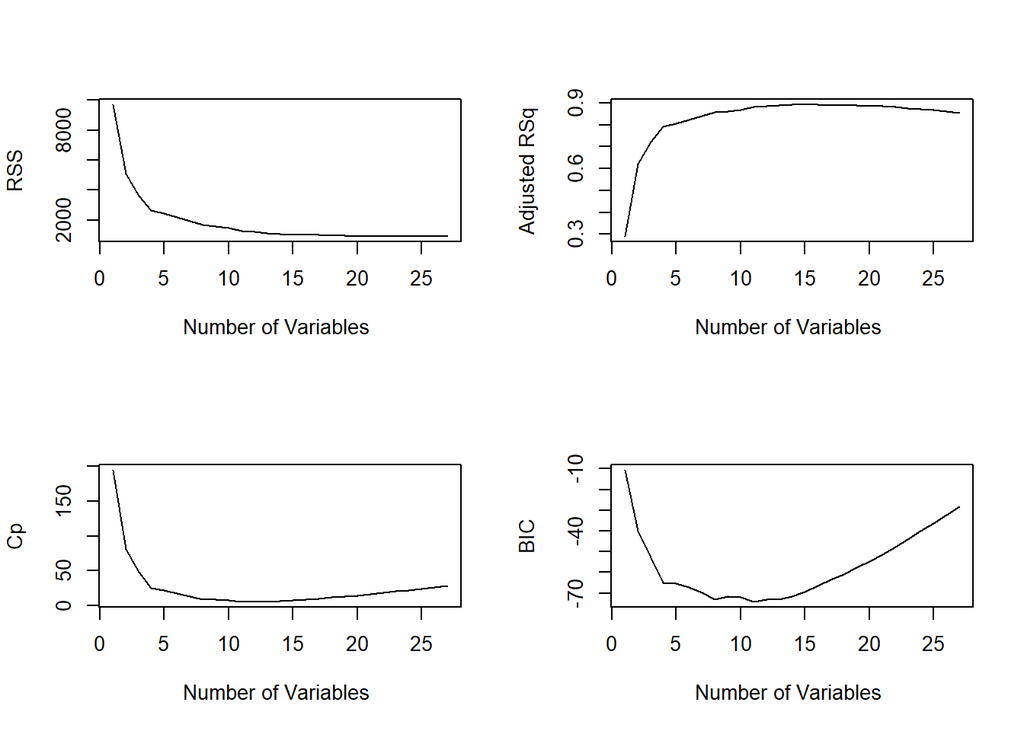

```r
regfit.full = regsubsets(target_death_rate ~ ., data = transformed_model_data_state, nvmax = 27)
reg.summary = summary(regfit.full)

par(mfrow=c(2, 2))
plot(reg.summary$rss ,xlab="Number of Variables ",ylab="RSS", type="l")

plot(reg.summary$adjr2 ,xlab="Number of Variables ",ylab="Adjusted RSq",type="l")

plot(reg.summary$cp,xlab="Number of Variables ",ylab="Cp",type="l")

plot(reg.summary$bic ,xlab="Number of Variables ",ylab="BIC",type="l")
```

```r
best <- function(model, ...)
{
  subsets <- regsubsets(formula(model), model.frame(model), nvmax = 27, ...)
  subsets <- with(summary(subsets),
                  cbind(p = as.numeric(rownames(which)), which, rss, rsq, adjr2, cp, bic))

  return(subsets)
}


tranformed_full = lm(target_death_rate ~ . , data = transformed_model_data_state)
round(best(tranformed_full, nbest = 1), 3)
```

```
##     p (Intercept) log_avg_ann_count incidence_rate inverse_med_income
## 1   1           1                 0              0                  0
## 2   2           1                 0              1                  0
## 3   3           1                 0              1                  0
## 4   4           1                 0              1                  0
## 5   5           1                 0              1                  0
## 6   6           1                 0              1                  0
## 7   7           1                 0              1                  0
## 8   8           1                 0              1                  0
## 9   9           1                 0              1                  0
## 10 10           1                 0              1                  0
## 11 11           1                 0              1                  0
## 12 12           1                 0              1                  0
## 13 13           1                 0              1                  1
## 14 14           1                 0              1                  1
```

[output cut: 237 more lines]

We arrive at a predictor model: incidence_rate, log_avg_household_size, pct_hs18_24, pct_bach_deg25_over, pct_white, pct_married_households, log_study_per_cap, and log_pct_black. The 8 predictor model is the smallest model that has a Cp less than the number of parameters. Furthermore, the adjusted Rsquared is not significantly different from the maximum adjusted Rsquared (0.858 vs. 0.893) and the BIC is not substantially different from teh minimum BIC (-72.921 vs. -74.161).

Now, determine if there are collinearity issues

```r
final_transformed  = lm(target_death_rate ~ incidence_rate + log_avg_household_size + pct_hs18_24 +
                               pct_bach_deg25_over + pct_white + pct_married_households +
                               log_study_per_cap + log_pct_black, data = transformed_model_data_state)

vif(final_transformed)
```

```
##         incidence_rate log_avg_household_size            pct_hs18_24
##               1.904557               1.422936               2.141975
##    pct_bach_deg25_over              pct_white pct_married_households
##               3.014298               3.260571               2.498583
##      log_study_per_cap          log_pct_black
##               2.985946               3.386269
```

There are no variables with VIF > 5. So, we arrive at a 8 predictor model with no collinearity issues: incidence_rate, log_avg_household_size, pct_hs18_24, pct_bach_deg25_over, pct_white, pct_married_households, log_study_per_cap, and log_pct_black

# Model Diagnostics

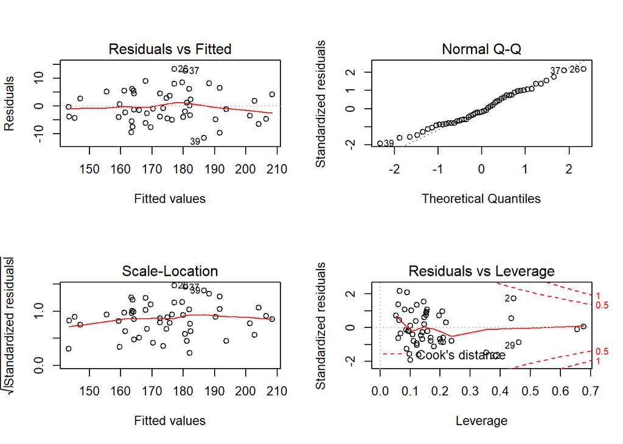

```r
par(mfrow=c(2,2))
plot(final_transformed)
```

Check for outliers, leverage, and influential points

```r
#find outlier in Y
stu_res = rstandard(final_transformed)
outliers_y = stu_res[abs(stu_res)>2.5]

outliers_y
```

```
## named numeric(0)
```

According to studentized residuals, there are no outliers in y. In the QQ plot, we see that point 37, 26, and 39 are potential outliers.

```r
distance = cooks.distance(final_transformed)
distance[distance > 0.5]
```

```
## named numeric(0)
```

There are no points that have a cook’s distance that is greater than 0.5. Therefore, we do not have influence points

# Comparison Models

1. Model with untransformed variables

Create the subset dataset with only the untransformed variables

```r
untransformed_model_data_state =
  model_data_state %>%
  dplyr::select(-starts_with("log"), -starts_with("inverse"), -starts_with("sqrt"))
```

Our full model has 27 potential predictors - select model based on criterion procedures

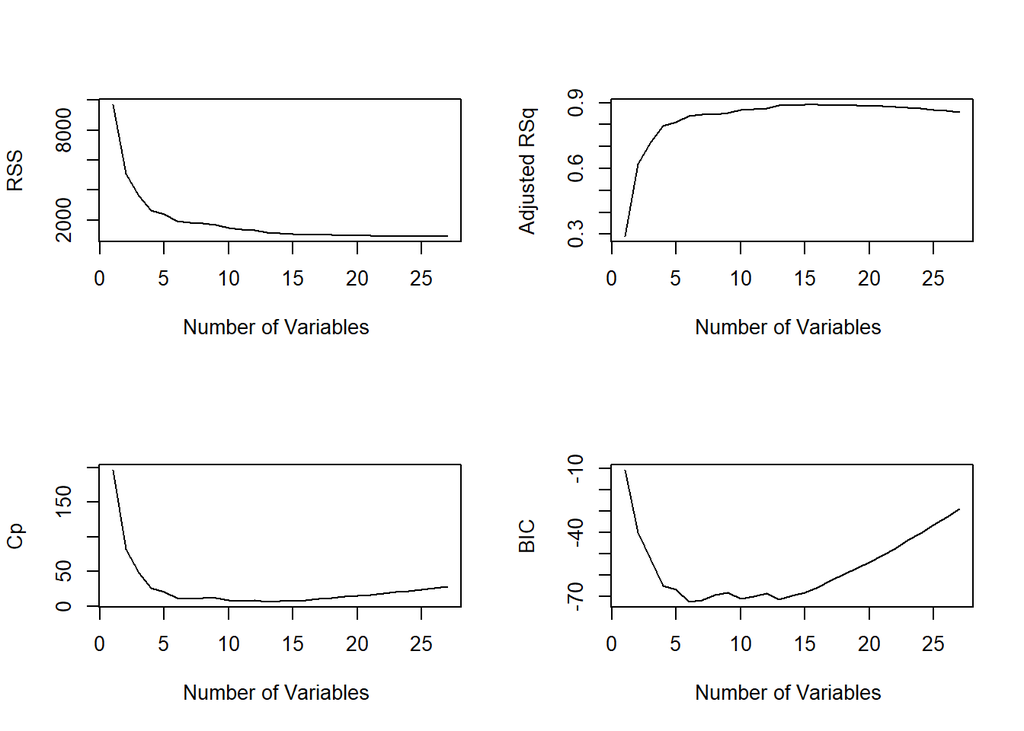

```r
regfit.full = regsubsets(target_death_rate ~ ., data = untransformed_model_data_state, nvmax = 27)
reg.summary = summary(regfit.full)

par(mfrow=c(2, 2))
plot(reg.summary$rss ,xlab="Number of Variables ",ylab="RSS", type="l")

plot(reg.summary$adjr2 ,xlab="Number of Variables ",ylab="Adjusted RSq",type="l")

plot(reg.summary$cp,xlab="Number of Variables ",ylab="Cp",type="l")

plot(reg.summary$bic ,xlab="Number of Variables ",ylab="BIC",type="l")
```

```r
best <- function(model, ...)
{
  subsets <- regsubsets(formula(model), model.frame(model), nvmax=27, ...)
  subsets <- with(summary(subsets),
                  cbind(p = as.numeric(rownames(which)), which, rss, rsq, adjr2, cp, bic))

  return(subsets)
}


untranformed_full = lm(target_death_rate ~ . , data = untransformed_model_data_state)
round(best(untranformed_full, nbest = 1), 3)
```

```
##     p (Intercept) avg_ann_count incidence_rate poverty_percent
## 1   1           1             0              0               0
## 2   2           1             0              1               0
## 3   3           1             0              1               0
## 4   4           1             0              1               0
## 5   5           1             0              1               0
## 6   6           1             0              1               0
## 7   7           1             1              1               0
## 8   8           1             1              1               0
## 9   9           1             0              1               0
## 10 10           1             0              1               0
## 11 11           1             0              1               0
## 12 12           1             0              1               0
## 13 13           1             0              1               0
## 14 14           1             0              1               0
```

[output cut: 209 more lines]

Now, determine if there are collinearity issues

```r
selected_untransformed  = lm(target_death_rate ~ incidence_rate + pct_asian + birth_rate +
                               med_income + avg_household_size + pct_other_race + percent_married +
                               pct_bach_deg25_over + pct_private_coverage + pct_married_households,
                             data = untransformed_model_data_state)

vif(selected_untransformed)
```

```
##         incidence_rate              pct_asian             birth_rate
##               2.375061               2.025649               2.821411
##             med_income     avg_household_size         pct_other_race
##               7.258778               5.074402               1.787202
##        percent_married    pct_bach_deg25_over   pct_private_coverage
##              37.200327               4.676865               6.383089
## pct_married_households
##              31.352095
```

The following variables have a VIF > 5: med_income, avg_household_size, percent_married, pct_private_coverage, and pct_married_households. We can find the correlations to determine what variables should remain in the model

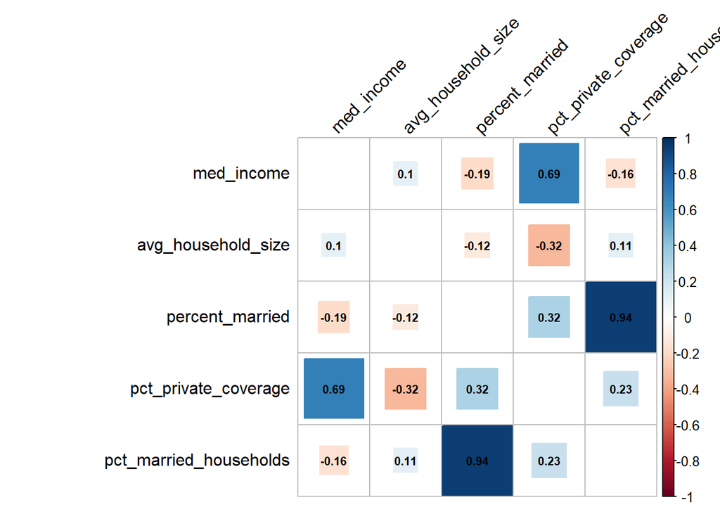

```r
correlation_check = untransformed_model_data_state %>%
  dplyr::select(med_income, avg_household_size, percent_married, pct_private_coverage,
                pct_married_households)

par(mfrow=c(1, 1))
cor(correlation_check)%>%
  corrplot(method = "square", addCoef.col = "black", tl.col="black", tl.srt=45, insig = "blank",
         diag=FALSE, number.cex = .7)
```

```r
final_untransformed_model  = lm(target_death_rate ~ incidence_rate + pct_asian + birth_rate +
                               med_income + avg_household_size + pct_other_race + percent_married +
                               pct_bach_deg25_over,
                             data = untransformed_model_data_state)

vif(final_untransformed_model)
```

```
##      incidence_rate           pct_asian          birth_rate
##            2.238731            1.813041            1.917726
##          med_income  avg_household_size      pct_other_race
##            3.848087            2.053039            1.752265
##     percent_married pct_bach_deg25_over
##            1.521627            3.527784
```

We arrive at a 8 predictor model with no collinearity issues: incidence_rate, pct_asian, birth_rate, med_income, avg_household_size, pct_other_race, percent_married, and pct_bach_deg25_over

2. Lasso Model

```r
attach(transformed_model_data_state)

library(glmnet)
```

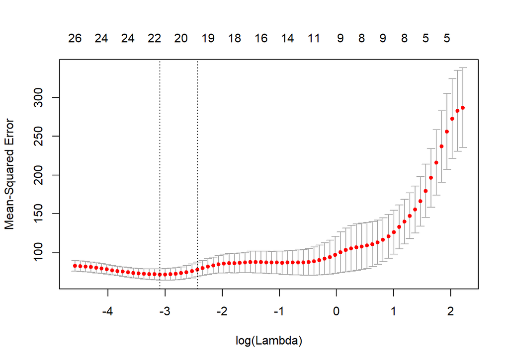

```r
test.mat = model.matrix(target_death_rate ~ ., data = transformed_model_data_state)[, -1]
lasso.mod = glmnet(test.mat, target_death_rate, alpha = 1)
set.seed(1)
cv.out = cv.glmnet(test.mat,target_death_rate,alpha=1)
par(mfrow=c(1, 1))
plot(cv.out)
```

```r
bestlam = cv.out$lambda.min
bestlam
```

```
## [1] 0.04544236
```

```r
out = glmnet (test.mat, target_death_rate, alpha=1)
lasso.coef = predict (out, type="coefficients", s= bestlam)
lasso.coef
```

```
## 28 x 1 sparse Matrix of class "dgCMatrix"
##                                            1
## (Intercept)                     2.291737e+02
## log_avg_ann_count               .
## incidence_rate                  1.858463e-01
## inverse_med_income             -1.047235e+06
## sqrt_poverty_percent           -9.734389e-02
## median_age_male                -8.844825e-01
## median_age_female               .
## log_avg_household_size          1.452829e+01
## percent_married                 2.371732e+00
## sqrt_pct_no_hs18_24             .
## pct_hs18_24                     1.058211e+00
## sqrt_pct_bach_deg18_24          5.733722e+00
## pct_hs25_over                   7.383018e-02
## pct_bach_deg25_over            -2.532562e+00
## pct_employed16_over             2.464112e-01
## sqrt_pct_unemployed16_over      4.241481e+00
## pct_private_coverage           -1.087220e+00
## pct_private_coverage_alone      .
## pct_emp_priv_coverage           9.083575e-05
## pct_public_coverage             .
## sqrt_pct_public_coverage_alone -4.753975e+00
## pct_white                       1.973167e-01
## pct_married_households         -2.891177e+00
## sqrt_birth_rate                -1.562258e+01
## log_study_per_cap              -1.308682e+00
## log_pct_black                   3.813869e+00
## log_pct_asian                   1.242544e+00
## log_other_race                 -3.838663e+00
```

```r
detach(transformed_model_data_state)
```

Lasso only eliminates five variables: log_avg_ann_count, median_age_female, sqrt_pct_no_hs18_24, pct_private_coverage_alone, and pct_public_coverage

# Model Validation

Compare the three models to determine which has the best predictive ability

Split the data into training and tesing sets

```r
cv_df =
  crossv_mc(model_data_state, 100) %>%
  mutate(train = map(train, as_tibble),
         test = map(test, as_tibble))
```

Calculate MSE for the three models (train and test)

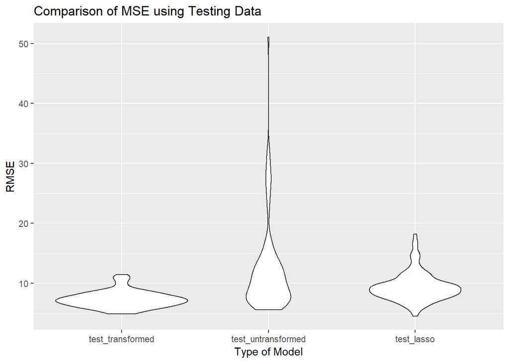

```r
cv_df =
  cv_df %>%
  mutate(transformed = map(train, ~lm(target_death_rate ~ incidence_rate + log_avg_household_size + pct_hs18_24 +
                               pct_bach_deg25_over + pct_white + pct_married_households +
                               log_study_per_cap + log_pct_black,  data = .x)),
         rmse_test_transformed = map2_dbl(transformed, test, ~rmse(model = .x, data = .y)),
         rmse_train_transformed = map2_dbl(transformed, train, ~rmse(model = .x, data = .y)),


         untransformed = map(train, ~lm(target_death_rate ~ incidence_rate + pct_asian + birth_rate +
                               med_income + avg_household_size + pct_other_race + percent_married +
                               pct_bach_deg25_over, data = .x)),
         rmse_test_untransformed = map2_dbl(untransformed, test, ~rmse(model = .x, data = .y)),
         rmse_train_untransformed = map2_dbl(untransformed, train, ~rmse(model = .x, data = .y)),

         lasso = map(train, ~lm(target_death_rate ~ incidence_rate + inverse_med_income + sqrt_poverty_percent +
                                median_age_male + log_avg_household_size + percent_married + pct_hs18_24 +
                                sqrt_pct_bach_deg18_24 + pct_hs25_over + pct_bach_deg25_over + pct_employed16_over +
                                sqrt_pct_unemployed16_over + pct_private_coverage + pct_emp_priv_coverage +
                                sqrt_pct_public_coverage_alone + pct_white + pct_married_households + sqrt_birth_rate +
                                log_study_per_cap + log_pct_black+log_pct_asian +log_other_race, data = .x)),
         rmse_test_lasso = map2_dbl(lasso, test, ~rmse(model = .x, data = .y)),
         rmse_train_lasso = map2_dbl(lasso, train, ~rmse(model = .x, data = .y))
         )

cv_df %>%
  dplyr::select(starts_with("rmse")) %>%
  gather(key = model, value = rmse) %>%
  mutate(model = str_replace(model, "rmse_", ""),
         model = fct_inorder(model)) %>%
  filter(model %in% c("test_transformed", "test_untransformed", "test_lasso"))%>%
  ggplot(aes(x = model, y = rmse)) + geom_violin()+
  labs(title = "Comparison of MSE using Testing Data",
       y = "RMSE",
       x = "Type of Model")
```

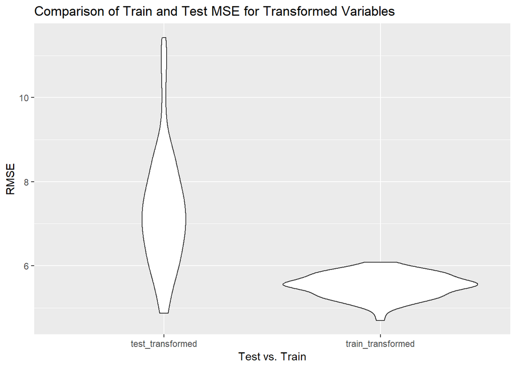

```r
cv_df %>%
  dplyr::select(starts_with("rmse")) %>%
  gather(key = model, value = rmse) %>%
  mutate(model = str_replace(model, "rmse_", ""),
         model = fct_inorder(model)) %>%
  filter(model %in% c("train_transformed", "test_transformed"))%>%
  ggplot(aes(x = model, y = rmse)) + geom_violin()+
  labs(title = "Comparison of Train and Test MSE for Transformed Variables",
       y = "RMSE",
       x = "Test vs. Train")
```

```r
mean(cv_df$rmse_test_transformed)
```

```
## [1] 7.322054
```

```r
mean(cv_df$rmse_train_transformed)
```

```
## [1] 5.525591
```

```r
mean(cv_df$rmse_test_untransformed)
```

```
## [1] 12.2752
```

```r
mean(cv_df$rmse_train_untransformed)
```

```
## [1] 6.821199
```

```r
mean(cv_df$rmse_test_lasso)
```

```
## [1] 9.430408
```

```r
mean(cv_df$rmse_train_lasso)
```

```
## [1] 3.859607
```

Our proposed model with transformed variable has the best predictive abilitity (lowest test MSE)